# 04 - Visualizing spatial data, and more

## Add title

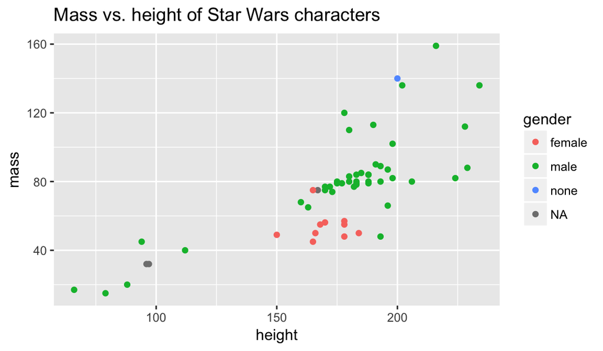

```r
ggplot(data = starwars, aes(x = height, y = mass, color = gender)) +
  geom_point() +
  labs(title = "Mass vs. height of Star Wars characters")
```

## Add x and y labels

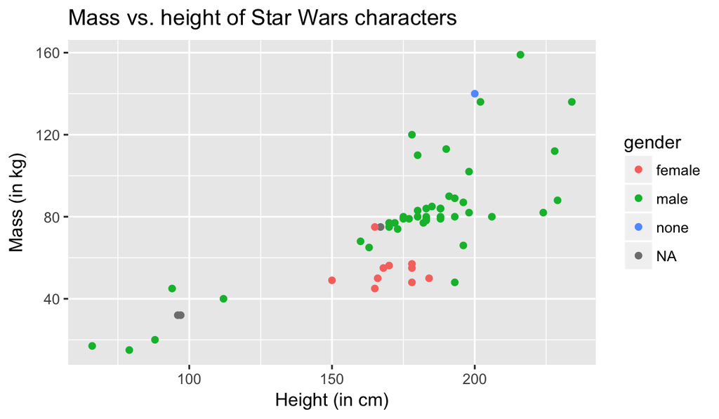

```r
ggplot(data = starwars, aes(x = height, y = mass, color = gender)) +
  geom_point() +
  labs(title = "Mass vs. height of Star Wars characters",
       x = "Height (in cm)", y = "Mass (in kg)")
```

## Change legend label

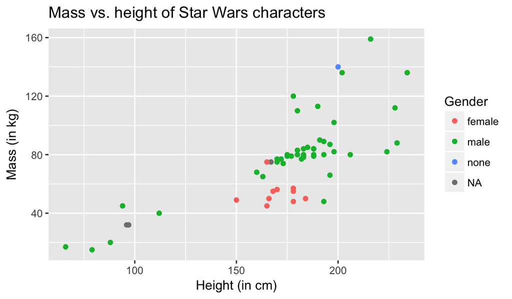

```r
ggplot(data = starwars, aes(x = height, y = mass, color = gender)) +
  geom_point() +
  labs(title = "Mass vs. height of Star Wars characters",
       x = "Height (in cm)", y = "Mass (in kg)", color = "Gender")
```

## Change zooming

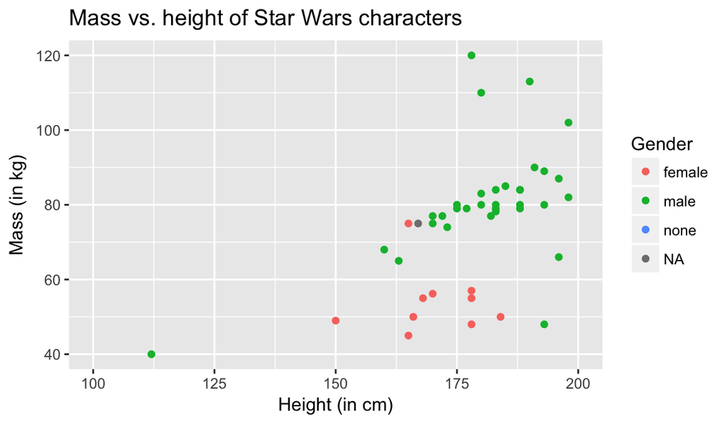

```r
ggplot(data = starwars, aes(x = height, y = mass, color = gender)) +
  geom_point() +
  labs(title = "Mass vs. height of Star Wars characters",
       x = "Height (in cm)", y = "Mass (in kg)", color = "Gender") +
  xlim(c(100, 200)) +
  ylim(c(40, 120))
```

## Change transparency

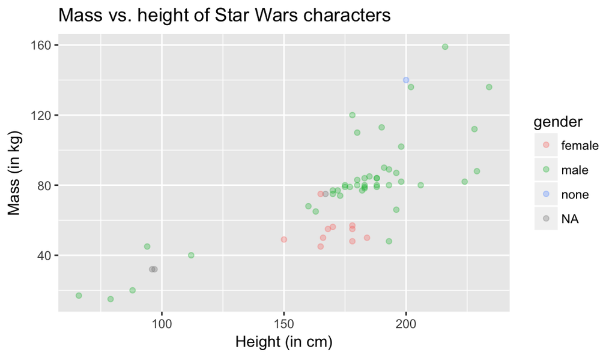

```r
ggplot(data = starwars, aes(x = height, y = mass, color = gender)) +
  geom_point(alpha = 0.3) +
  labs(title = "Mass vs. height of Star Wars characters",
       x = "Height (in cm)", y = "Mass (in kg)", fill = "Gender")
```

## Change theme

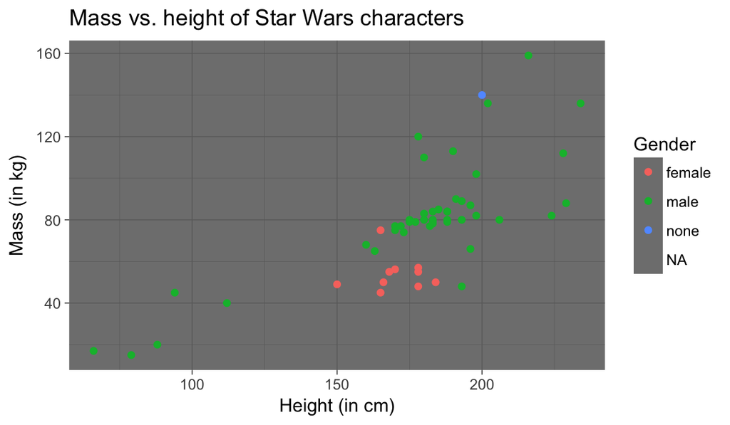

```r
ggplot(data = starwars, aes(x = height, y = mass, color = gender)) +
  geom_point() +
  labs(title = "Mass vs. height of Star Wars characters",
       x = "Height (in cm)", y = "Mass (in kg)", color = "Gender") +
  theme_dark()
```

## Change theme

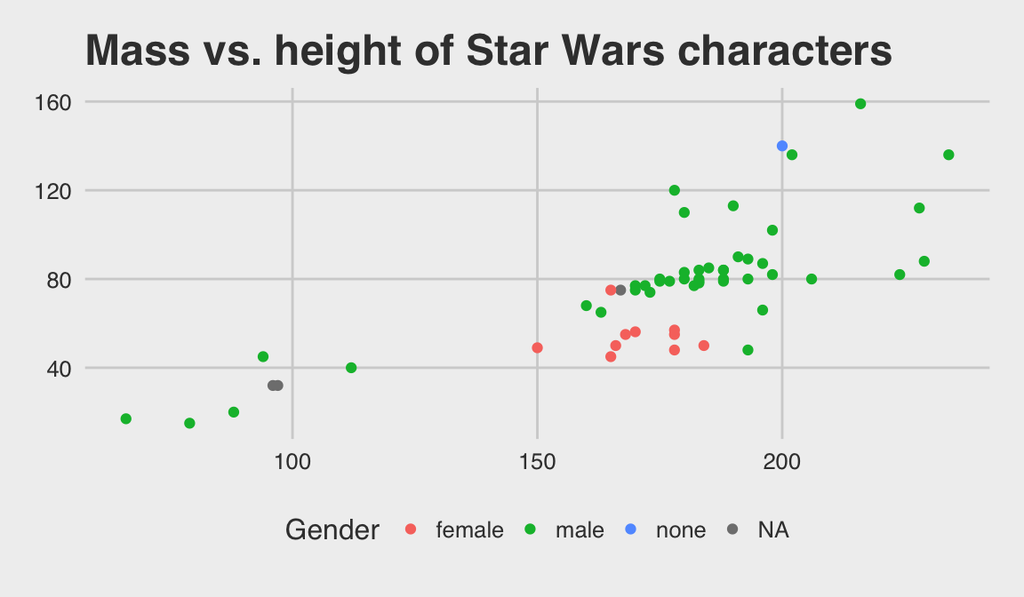

```r
# install.packages("ggthemes")
library(ggthemes)

ggplot(data = starwars, aes(x = height, y = mass, color = gender)) +
  geom_point() +
  labs(title = "Mass vs. height of Star Wars characters",
       x = "Height (in cm)", y = "Mass (in kg)", color = "Gender") +
  theme_fivethirtyeight()
```

## Further customization

- It is possible to do a lot more customization to your plots
- See http://ggplot2.tidyverse.org/ for help on using the ggplot2 package
  - You can find a list of all ggplot2 functions in the Reference tab of the package homepage
- You'll find that sometimes customization is valuable, and sometimes the defaults work well and while customization might be doable (technically) it might not be necessary

## Visualizing spatial data

## Spatial data

- Also known as geospatial data or geographic information it is the data or information that identifies the geographic location of features and boundaries on Earth, such as natural or constructed features, oceans, and more.
- Spatial data is usually stored as coordinates and topology, and is data that can be mapped.

## Hurricane Irma

**TEAM:** Sketch what a tidy data frame that could be used to generate the following map depicting where Hurricane Irma is headed would look like, i.e. what's in the rows, and what's in the columns? (See original interactive map at https://nyti.ms/2x7nKLD.)

[figure not shown]

## Sweetened carbonated beverage

Describe the spatial distribution of preferred sweetened carbonated beverage drink.

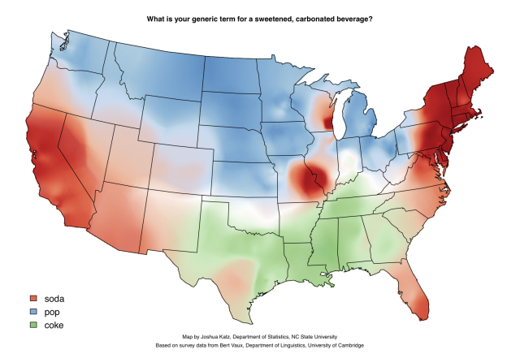

## Hey y'all!

What is missing in this visualization?

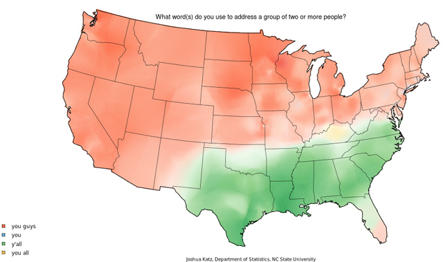

## Wrapping up

## Assignment(s)

- Will post instructions on caching password for GitHub, follow along, ask on Slack if you get stuck, come to OH on Monday and we can do it together
- Mini Homework 04